# 2020 Election Analysis

Dave Anderson

November 29, 2020

# Introduction

Personally, I do not spend much time learning about the day to day events of politics, and I believe we spend too much time as a country focusing on irrelevant nuances of our elections. That said, the presidential election is a beautiful opportunity to get a pulse of the nation’s mindset as a whole. There are plenty of better ways to do this in our data-driven world, but election data is assumed to be accurate, representative of everyone and, most importantly, it is available to the public (me). From what I did hear and read in the news, most of the election was focused on dividing the poluations into subgroups, specifically by rural, suburban and urban populations as well as race and gender. Each party assumed they had certain groups in control (ex. urban minorities for Biden) while other groups appeared to be swing potentials and became the focus of campaign strategies (ex. suburban women). Although the candidates searched for potential groups to gain votes from, the nation appeared to be more divided and set in their views leading into the election then ever. Both Republican and Democrat populations appear to have a growing section of supporters who no longer view the oposing side as peers with varying values and ideas, but as an inferior and less intelligent population misaligned with American values.

There is hypocracy in this project, because although I encourage a focus on policy, civil discourse and avoidance of over-generalizations, this report is a “necessary evil” oposition to those principals. From a national perspective, are we truly as divided along these demographic and location indicators as our media describes? Are there common characteristics that distingush these populations? Are there characteristics that unite these populations as Americans facing common issues? These are important questions to address, even if there aren’t exact answers. Every county in our country is unique in a variety of ways, all of which leading to the data in these visualizations. Our job as problem solvers is often to either zoom in or out. Since the topic of conversation is national divide, it is only right to zoom out.

Disclaimer on legitamacy of election results: Every election has ballots missed, miscounted, falsified, etc. Our voting process is living in the stone ages, and polititians generally seem to like it that way. We have had some incredible statisticians and investigators doing very challenging work to ensure an accurate outcome. Any counter opinion to that fact which relies on individual stories reported by a biased media outlet should be dismissed while being compared to experts who have dedicated their lives to understand the content of the problem.

# Data and Methods

The base dataset of county-level presidential election results comes Thomson Reuters, and although I chose to focus on the two frontrunners, there is data for other candidates as well. This data can be easily downloaded via Kaggle. I supplimented this data with county-level statistics from a variety of sources. The focus of these additional variables became around edcuation and income, utilizing ers.usda.gov, data.gov and census.gov.

After combining the datasets into a master, county-level dataframe, I engineered a number of variables for more appropriate calculations and additional insights, including an opportunity to specifically investigate prevelance of manufactoring and other industries. Overall investigations of the election results began with a simple EDA to address the questions posed in the introduction. Finally, I created a logistic regression model with key variables as predictors to determine the largest drivers of how a county voted.

| Environment | n Counties | Population (Thousands) | Percent of Counties for Trump | Median Black Population | Median White Population | Median Income | Median College Graduation | Voting Rate |
| --- | --- | --- | --- | --- | --- | --- | --- | --- |
| Rural | 1028 | 12,162 | 92 % | 1 % | 94 % | $ 46,975 | 17.7 % | 52 % |
| Suburban | 855 | 31,609 | 89 % | 2.3 % | 92 % | $ 48,384 | 17.1 % | 47 % |
| Urban | 1063 | 263,019 | 74 % | 5.7 % | 87.2 % | $ 57,979 | 24.1 % | 49 % |

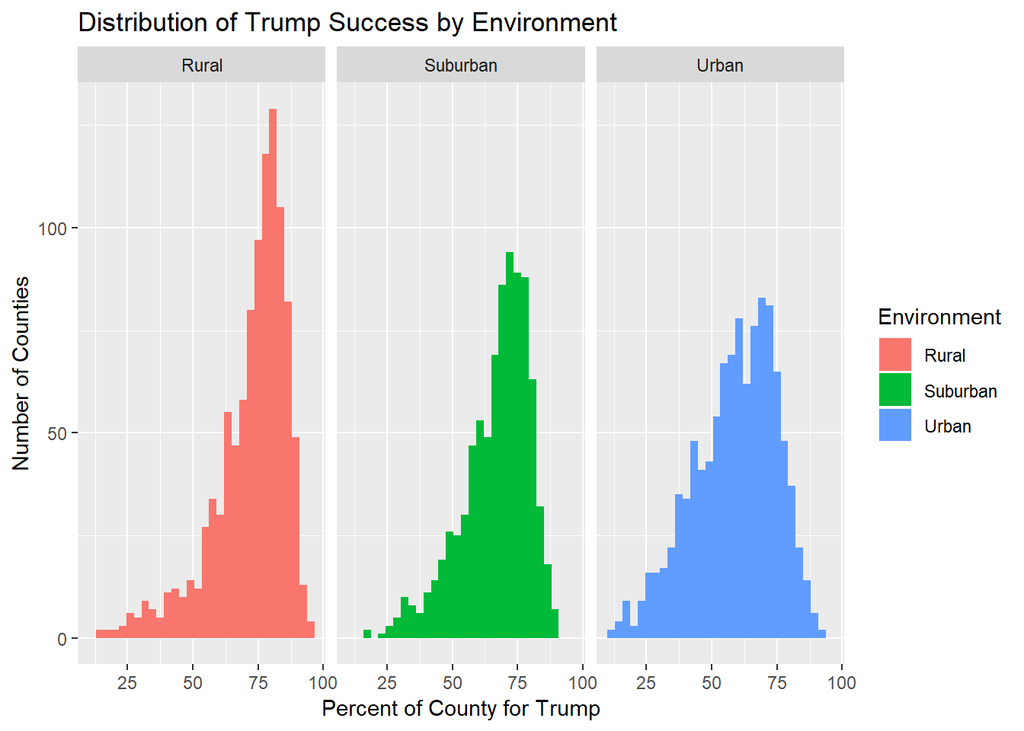

There are a few notable surprises from the general summary table above. For one, while many of us have an image in our head of urban blue, there are actually more urban counties voting for trump than not. I think people would also agree that the college education and income statistics would be expected to be much higher, especially compared to the rural.

# Results

### Education

The liberal media tends to paint supporters of Donald Trump as unedcutated and therefore more suseptable to misinformation. Between social media, the entertainment-driven divide of our network news stations, and a dying print media, misinformation is a critical topic to address in our nation. I would argue an effective formal education that helps train our citizens how to research and vet information is the best way to combat misinformation, and the chart below shows there is some evidence to support the idea that populations voting for Trump were, in general, more succeptable to misinformation.

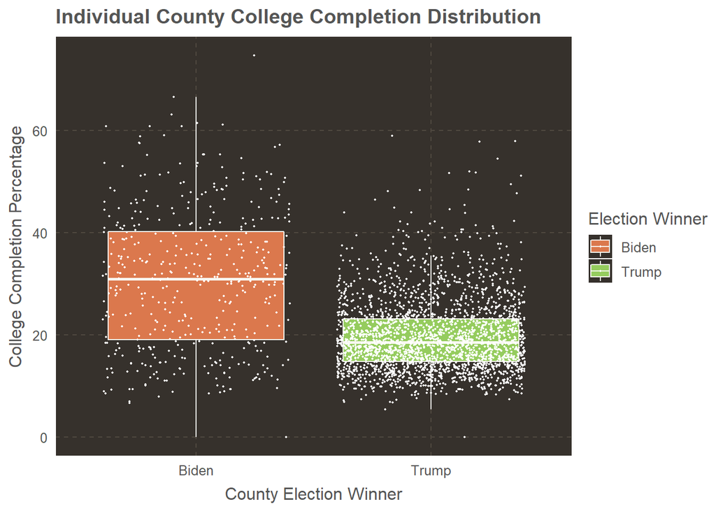

To quote the former president, it is what it is. Say what you want about the value of a formal education, as a former educator, I focus on it as a vital part of a functioning modern society. More important to me than this snapshot description of the two voting populations, I want to know how education in America has been changing. Many people point to the fact that misinformation can be a biproduct of an increasingly digital world, and therefore we must be becoming “dumber” as time goes on. The first set of plots below tells a different story, a drastic decrease of high school dropouts combined with an increase of college education across all environments of our country. I would argue that this is partly due to a lowering of expectations, but that is a discussion for another time. What is interesting is that when we plot the same information split out as “Biden” counties vs. “Trump” counties, we would expect to see a similar pattern. However, we do see that the current Republican population has not grown in college education in the same way that the country as a whole has. Why do people lack education? Some people leave formal education for a career oportunity that doesn’t require it, but the plots by year are evidence that these opportunities are decreasing. Access to education should be less of an issue in the modern world, with plenty of loan options and online courses. My experience leads me to believe that those who lack formal education typically do so because they do not personally see the value of it. As a proponent of education reform, I understand the complaints, but the final chart of this section shows that education directly relates to financial stability for all environments of our nation.

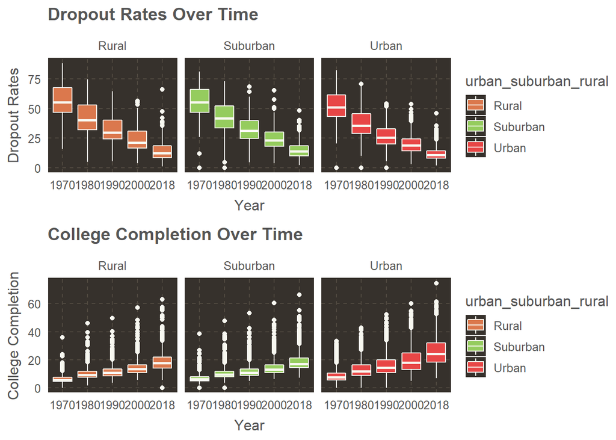

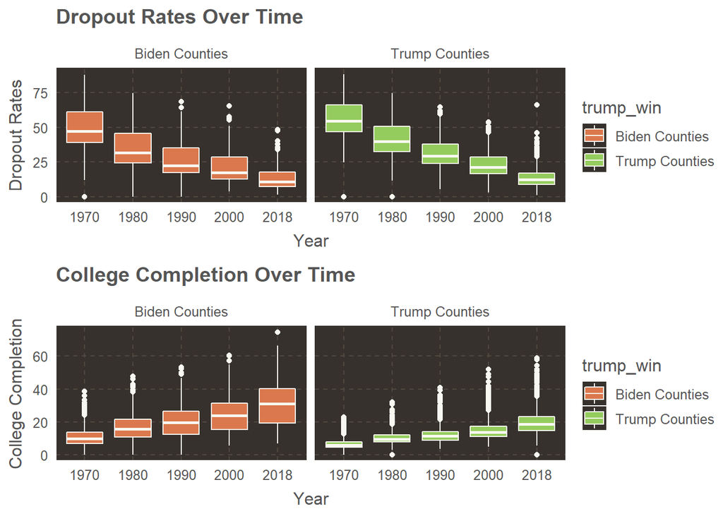

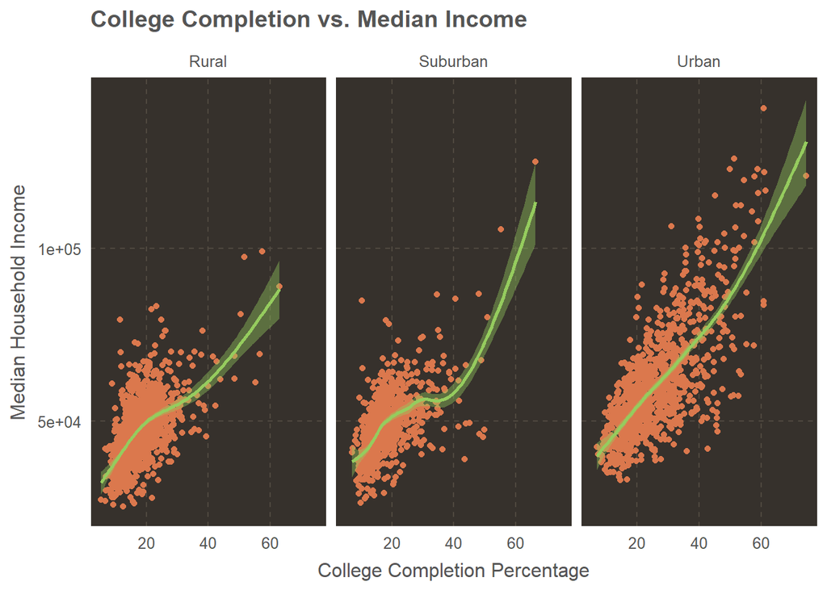

### Race

Another hot topic this election cycle has been a racial divide, spurred on by the killings of George Floyd and other black men and women. Unfortunetly without individual records, it is difficult to address any critical questions in this context. How successful are black individuals in each county compared to white individuals? How are voting lines drawn along race within counties? Is everyone treated respectfully and given the same access to success and happiness, regardless of race? These are obviously questions I can’t, and shouldn’t be able to, answer using publicly available data.

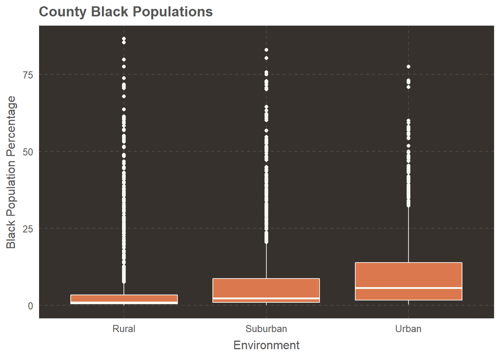

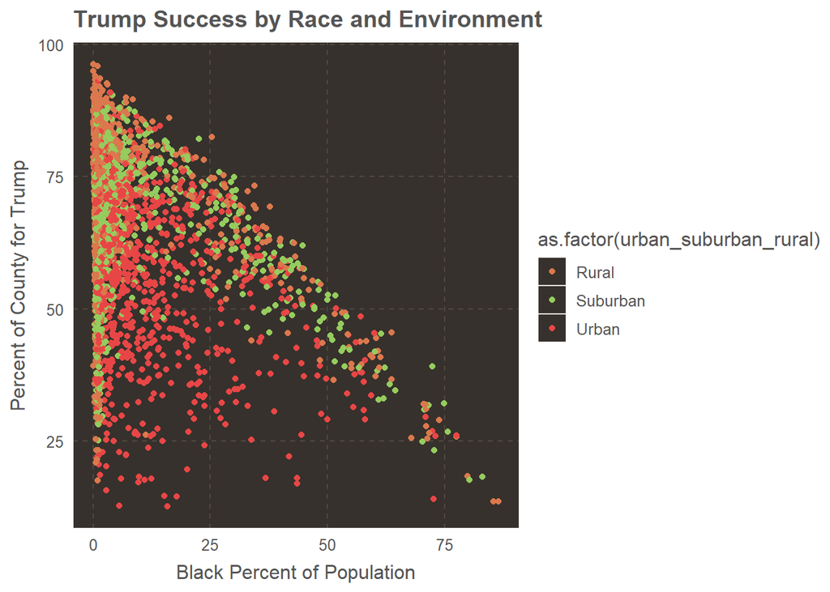

## Economics

Forever a critical topic, we want to know how financially stable our communities are. This has also always been a focal point of policy for both Trump and his supporters. In 2020, the most important aspect of the economy, and our lives, is the impact of COVID-19. Interestingly, the county-level infection and death data does not show many significant trends pertaining to election results, and short-term, county-level employment and economic numbers to show the impact of the virus on county economies are difficult to come by. The perception of voting populations’ economic standings tends to focus on the tails. When republicans think of democrats, they often refer to empoverished, homeless city-dwellers, feeding off of public support, as well as powerful, wealthy, corupt, corporate giants. When the tables are turned, you will often hear liberals imagining conservatives as “trailer-trash” or, again, corupt corporate giants. When we look at the distributions of poverty rates and income, we see the misleading aspects to these assumptions. First, the apex of poverty rates for Biden counties is slightly left of the apex for Trump counties, indicating that edcucation and social programs pay off. However, the right tail is much wider, indicating a greater number of empoverished populations. We also see this wider spread of income for democrat counties. (Note: sample size difference will also contribute to wider tails for Biden distributions.)

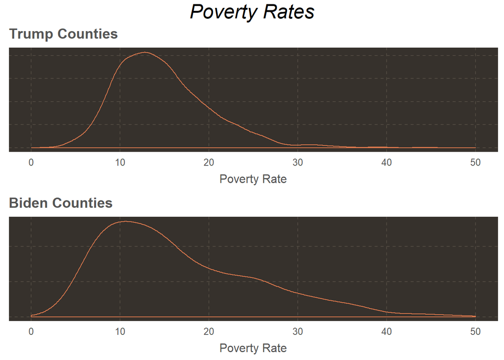

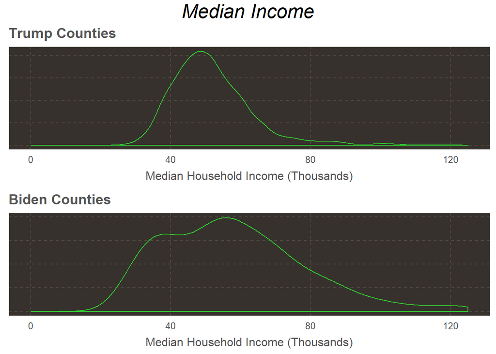

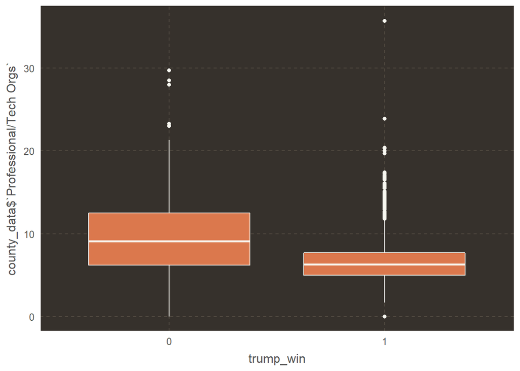